# Big Data Test

Sidney Hann

05 November, 2019

Above is the YAML, using the `params` option to set the date.

## 0.1 Global Settings

This next code chunk is visible in our RMarkdown document and within this code chunk the options for `knitr` will be set up. Since the option for the code chunk is `include=FALSE` this code chunk will not be printed in our final knitted report.

## 0.2 Set Up Library

Using the `library` statement we can load the tidyverse. This will allow us to use pipes, `%>%` to subset our code and make it look cleaner.

```r
library(tidyverse)
```

## 0.3 Load Data

This next code chunk will use a dataset, `Excitement`, to showcase the ability of RMarkdown to encorperate code, output, and Markdown to generate a easily readable, and reproducable report.

```r
Excitement <- read.csv(file = "Excite.csv")
```

## 0.4 Make a Plot of Satisfaction by Length of Presentation in Minutes With Code Showing

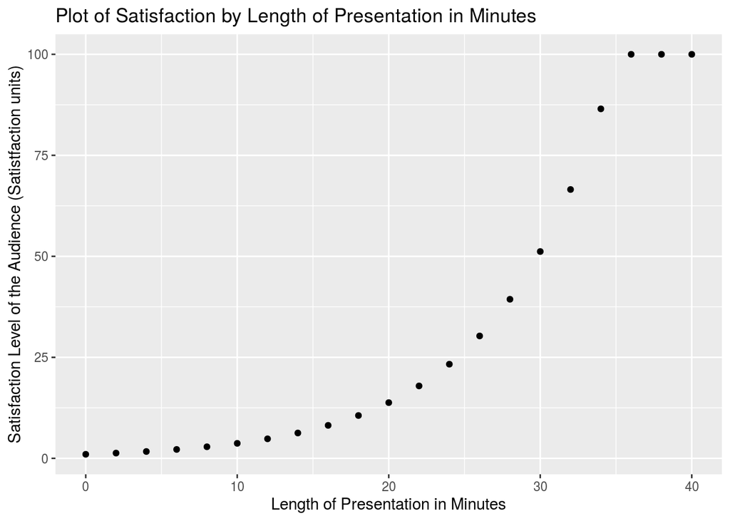

```r
Excitement %>%
  ggplot(mapping = aes(x=Length_of_Presentation, y=Satisfaction_From_Presentation_Real)) + #our aes statement will tell R which variables we would like on each axis
  geom_point() + #geom_point is used to make the scatterplot
  xlab("Length of Presentation in Minutes") +
  ylab("Satisfaction Level of the Audience (Satistfaction units)") + #xlab and ylab are used to make our axis more readable
  ggtitle("Plot of Satisfaction by Length of Presentation in Minutes")
```

## 0.5 Make a Plot of Satisfaction by Length of Presentation in Minutes Without Code Showing (echo = FALSE)

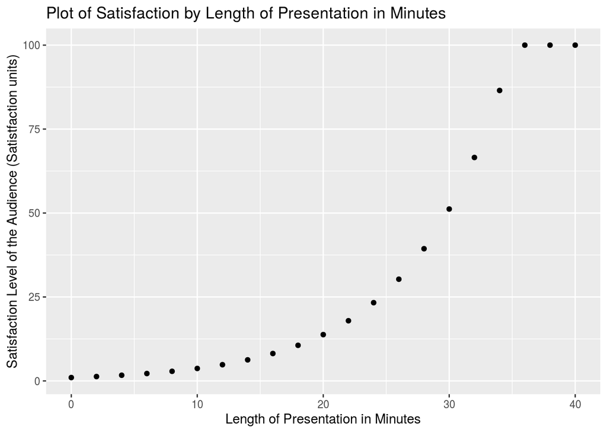

## 0.6 Knitting

So now you have your RMarkdown code laid out. What to do now?

KNIT!

As Rachel mentioned, there are three ways to do this:

1. Click the “Knit” button
2. Press Ctrl+Shift+K
3. With the code `rmarkdown::render(“inputfile.Rmd”)